# v4

##### Correlation for excel

pd.DataFrame(list_corr,columns=['Corr'])

df_train.corr()

#### Boxplot

```python
!jupyter nbconvert --to html --template  C:/Users/Megelon/Documents/v4.ipynb
```

```
[NbConvertApp] Converting notebook C:/Users/Megelon/Documents/v4.ipynb to html
[NbConvertApp] Writing 2191391 bytes to C:/Users/Megelon/Documents\v4.html
```

#### Excel type variables

df_types.reset_index().sort_values('index')

# House Pricing

Ask a home buyer to describe their dream house, and they probably won't begin with the height of the basement ceiling or the proximity to an east-west railroad. But this playground competition's dataset proves that much more influences price negotiations than the number of bedrooms or a white-picket fence.

With 79 explanatory variables describing (almost) every aspect of residential homes in Ames, Iowa, this competition challenges you to predict the final price of each home.

# Practice

Advanced regression techniques like random forest and gradient boosting

# Goal

It is your job to predict the sales price for each house. For each Id in the test set, you must predict the value of the SalePrice variable.

# Metric

Submissions are evaluated on Root-Mean-Squared-Error (RMSE) between the logarithm of the predicted value and the logarithm of the observed sales price. (Taking logs means that errors in predicting expensive houses and cheap houses will affect the result equally.)

# Submission File Format

The file should contain a header and have the following format:

Id,SalePrice

1461,169000.1

1462,187724.1233

1463,175221

etc.

# File descriptions

train.csv - the training set test.csv - the test set data_description.txt - full description of each column, originally prepared by Dean De Cock but lightly edited to match the column names used here sample_submission.csv - a benchmark submission from a linear regression on year and month of sale, lot square footage, and number of bedrooms

# Data fields

Here's a brief version of what you'll find in the data description file.

SalePrice - the property's sale price in dollars. This is the target variable that you're trying to predict.

MSSubClass: The building class

MSZoning: The general zoning classification

LotFrontage: Linear feet of street connected to property

LotArea: Lot size in square feet

Street: Type of road access

Alley: Type of alley access

LotShape: General shape of property

LandContour: Flatness of the property

Utilities: Type of utilities available

LotConfig: Lot configuration

LandSlope: Slope of property

Neighborhood: Physical locations within Ames city limits

Condition1: Proximity to main road or railroad

Condition2: Proximity to main road or railroad (if a second is present)

BldgType: Type of dwelling

HouseStyle: Style of dwelling

OverallQual: Overall material and finish quality

OverallCond: Overall condition rating

YearBuilt: Original construction date

YearRemodAdd: Remodel date

RoofStyle: Type of roof

RoofMatl: Roof material

Exterior1st: Exterior covering on house

Exterior2nd: Exterior covering on house (if more than one material)

MasVnrType: Masonry veneer type

MasVnrArea: Masonry veneer area in square feet

ExterQual: Exterior material quality

ExterCond: Present condition of the material on the exterior

Foundation: Type of foundation

BsmtQual: Height of the basement

BsmtCond: General condition of the basement

BsmtExposure: Walkout or garden level basement walls

BsmtFinType1: Quality of basement finished area

BsmtFinSF1: Type 1 finished square feet

BsmtFinType2: Quality of second finished area (if present)

BsmtFinSF2: Type 2 finished square feet

BsmtUnfSF: Unfinished square feet of basement area

TotalBsmtSF: Total square feet of basement area

Heating: Type of heating

HeatingQC: Heating quality and condition

CentralAir: Central air conditioning

Electrical: Electrical system

1stFlrSF: First Floor square feet

2ndFlrSF: Second floor square feet

LowQualFinSF: Low quality finished square feet (all floors)

GrLivArea: Above grade (ground) living area square feet

BsmtFullBath: Basement full bathrooms

BsmtHalfBath: Basement half bathrooms

FullBath: Full bathrooms above grade

HalfBath: Half baths above grade

Bedroom: Number of bedrooms above basement level

Kitchen: Number of kitchens

KitchenQual: Kitchen quality

TotRmsAbvGrd: Total rooms above grade (does not include bathrooms)

Functional: Home functionality rating

Fireplaces: Number of fireplaces

FireplaceQu: Fireplace quality

GarageType: Garage location

GarageYrBlt: Year garage was built

GarageFinish: Interior finish of the garage

GarageCars: Size of garage in car capacity

GarageArea: Size of garage in square feet

GarageQual: Garage quality

GarageCond: Garage condition

PavedDrive: Paved driveway

WoodDeckSF: Wood deck area in square feet

OpenPorchSF: Open porch area in square feet

EnclosedPorch: Enclosed porch area in square feet

3SsnPorch: Three season porch area in square feet

ScreenPorch: Screen porch area in square feet

PoolArea: Pool area in square feet

PoolQC: Pool quality

Fence: Fence quality

MiscFeature: Miscellaneous feature not covered in other categories

MiscVal: $Value of miscellaneous feature

MoSold: Month Sold

YrSold: Year Sold

SaleType: Type of sale

SaleCondition: Condition of sale

# Inicial

```python
import pandas as pd
import numpy as np
from matplotlib import pyplot as plt
```

```python
pd.options.display.height = 10
pd.options.display.max_rows = 4000
pd.options.display.max_columns = 4000

#pd.options.display.max_colwidth= -1
#pd.set_option('display.height', 1000)
#pd.set_option('display.max_rows', 500)
#pd.set_option('display.max_columns', 500)
#pd.set_option('display.width', 1000)
```

```
height has been deprecated.
```

# Datos

```python
df_train_bk= pd.read_csv('C:\\Users\\Megelon\\Downloads\\house-prices-advanced-regression-techniques\\train.csv')

df_train= pd.read_csv('C:\\Users\\Megelon\\Downloads\\house-prices-advanced-regression-techniques\\train.csv')

print(df_train.shape)

df_train=df_train.drop("Id",axis=1)
df_train.head()
```

```
(1460, 81)
```

|  | MSSubClass | MSZoning | LotFrontage | LotArea | Street | Alley | LotShape | LandContour | Utilities | LotConfig | LandSlope | Neighborhood | Condition1 | Condition2 | BldgType | HouseStyle | OverallQual | OverallCond | YearBuilt | YearRemodAdd | RoofStyle | RoofMatl | Exterior1st | Exterior2nd | MasVnrType | MasVnrArea | ExterQual | ExterCond | Foundation | … |
| --- | --- | --- | --- | --- | --- | --- | --- | --- | --- | --- | --- | --- | --- | --- | --- | --- | --- | --- | --- | --- | --- | --- | --- | --- | --- | --- | --- | --- | --- | --- |
| 0 | 60 | RL | 65.0 | 8450 | Pave | NaN | Reg | Lvl | AllPub | Inside | Gtl | CollgCr | Norm | Norm | 1Fam | 2Story | 7 | 5 | 2003 | 2003 | Gable | CompShg | VinylSd | VinylSd | BrkFace | 196.0 | Gd | TA | PConc | … |
| 1 | 20 | RL | 80.0 | 9600 | Pave | NaN | Reg | Lvl | AllPub | FR2 | Gtl | Veenker | Feedr | Norm | 1Fam | 1Story | 6 | 8 | 1976 | 1976 | Gable | CompShg | MetalSd | MetalSd | None | 0.0 | TA | TA | CBlock | … |
| 2 | 60 | RL | 68.0 | 11250 | Pave | NaN | IR1 | Lvl | AllPub | Inside | Gtl | CollgCr | Norm | Norm | 1Fam | 2Story | 7 | 5 | 2001 | 2002 | Gable | CompShg | VinylSd | VinylSd | BrkFace | 162.0 | Gd | TA | PConc | … |
| 3 | 70 | RL | 60.0 | 9550 | Pave | NaN | IR1 | Lvl | AllPub | Corner | Gtl | Crawfor | Norm | Norm | 1Fam | 2Story | 7 | 5 | 1915 | 1970 | Gable | CompShg | Wd Sdng | Wd Shng | None | 0.0 | TA | TA | BrkTil | … |
| 4 | 60 | RL | 84.0 | 14260 | Pave | NaN | IR1 | Lvl | AllPub | FR2 | Gtl | NoRidge | Norm | Norm | 1Fam | 2Story | 8 | 5 | 2000 | 2000 | Gable | CompShg | VinylSd | VinylSd | BrkFace | 350.0 | Gd | TA | PConc | … |

```python
columns_alfabetical=pd.DataFrame(df_train.columns).sort_values(by=0)[0].tolist()

df_train=df_train[columns_alfabetical]#.set_index('Id')
df_train.head()
```

|  | 1stFlrSF | 2ndFlrSF | 3SsnPorch | Alley | BedroomAbvGr | BldgType | BsmtCond | BsmtExposure | BsmtFinSF1 | BsmtFinSF2 | BsmtFinType1 | BsmtFinType2 | BsmtFullBath | BsmtHalfBath | BsmtQual | BsmtUnfSF | CentralAir | Condition1 | Condition2 | Electrical | EnclosedPorch | ExterCond | ExterQual | Exterior1st | Exterior2nd | Fence | FireplaceQu | Fireplaces | Foundation | … |
| --- | --- | --- | --- | --- | --- | --- | --- | --- | --- | --- | --- | --- | --- | --- | --- | --- | --- | --- | --- | --- | --- | --- | --- | --- | --- | --- | --- | --- | --- | --- |
| 0 | 856 | 854 | 0 | NaN | 3 | 1Fam | TA | No | 706 | 0 | GLQ | Unf | 1 | 0 | Gd | 150 | Y | Norm | Norm | SBrkr | 0 | TA | Gd | VinylSd | VinylSd | NaN | NaN | 0 | PConc | … |
| 1 | 1262 | 0 | 0 | NaN | 3 | 1Fam | TA | Gd | 978 | 0 | ALQ | Unf | 0 | 1 | Gd | 284 | Y | Feedr | Norm | SBrkr | 0 | TA | TA | MetalSd | MetalSd | NaN | TA | 1 | CBlock | … |
| 2 | 920 | 866 | 0 | NaN | 3 | 1Fam | TA | Mn | 486 | 0 | GLQ | Unf | 1 | 0 | Gd | 434 | Y | Norm | Norm | SBrkr | 0 | TA | Gd | VinylSd | VinylSd | NaN | TA | 1 | PConc | … |
| 3 | 961 | 756 | 0 | NaN | 3 | 1Fam | Gd | No | 216 | 0 | ALQ | Unf | 1 | 0 | TA | 540 | Y | Norm | Norm | SBrkr | 272 | TA | TA | Wd Sdng | Wd Shng | NaN | Gd | 1 | BrkTil | … |
| 4 | 1145 | 1053 | 0 | NaN | 4 | 1Fam | TA | Av | 655 | 0 | GLQ | Unf | 1 | 0 | Gd | 490 | Y | Norm | Norm | SBrkr | 0 | TA | Gd | VinylSd | VinylSd | NaN | TA | 1 | PConc | … |

#### Variables Types

The data set have 80 variables

1 continuous, target

36 continuous , explanatory

43 categorical , explanatory

```python
df_types=pd.DataFrame(df_train.dtypes, columns=['type'])
print(df_types.shape)
#print(df_types.reset_index().sort_values('type'))
print('categorical')
print(len(df_types[df_types.type=='object'].reset_index()['index'].tolist()))
print('continuous')
print(len(df_types[df_types.type!='object'].reset_index()['index'].tolist()))
```

```
(80, 1)
categorical
43
continuous
37
```

### But this ones are also categorical

MSSubClass

OverallQual

OverallCond

MoSold

YrSold

```python
transform_vars_to_strings=["YrSold", "OverallQual", "OverallCond"]
df_train[transform_vars_to_strings] = df_train[transform_vars_to_strings].apply(pd.to_numeric)
df_types=pd.DataFrame(df_train.dtypes, columns=['type'])
print(df_types.shape)
#print(df_types.reset_index().sort_values('type'))
print('categorical')
print(len(df_types[df_types.type=='object'].reset_index()['index'].tolist()))
print('continuous')
print(len(df_types[df_types.type!='object'].reset_index()['index'].tolist()))
```

```
(80, 1)
categorical
43
continuous
37
```

```python
df_train.YrSold.describe()
```

```
count    1460.000000
mean     2007.815753
std         1.328095
min      2006.000000
25%      2007.000000
50%      2008.000000
75%      2009.000000
max      2010.000000
Name: YrSold, dtype: float64
```

```python
df_train.MoSold.describe()
```

```
count    1460.000000
mean        6.321918
std         2.703626
min         1.000000
25%         5.000000
50%         6.000000
75%         8.000000
max        12.000000
Name: MoSold, dtype: float64
```

```python
df_train['YearsBuilt']=2011-df_train['YrSold']+(12-df_train['MoSold'])/12
df_train.YearsBuilt.describe()
```

```
count    1460.000000
mean        3.657420
std         1.314303
min         1.416667
25%         2.500000
50%         3.583333
75%         4.666667
max         5.916667
Name: YearsBuilt, dtype: float64
```

```python
df_types=pd.DataFrame(df_train.dtypes, columns=['type'])
print(df_types.shape)
#print(df_types.reset_index().sort_values('type'))
print('categorical')
print(len(df_types[df_types.type=='object'].reset_index()['index'].tolist()))
print('continuous')
print(len(df_types[df_types.type!='object'].reset_index()['index'].tolist()))
```

```
(81, 1)
categorical
43
continuous
38
```

# Acá voy!

Borrar variables, de multicolinealidad, usadas para crear nuevas variables

Borrar variables de fecha, que se usaron para calcular antiguedad

```python
df_train=df_train.drop(['YrSold','MoSold'],axis=1)
df_train.shape
```

```
(1460, 79)
```

# Target variable

```python
df_train['SalePrice'].describe()
```

```
count      1460.000000
mean     180921.195890
std       79442.502883
min       34900.000000
25%      129975.000000
50%      163000.000000
75%      214000.000000
max      755000.000000
Name: SalePrice, dtype: float64
```

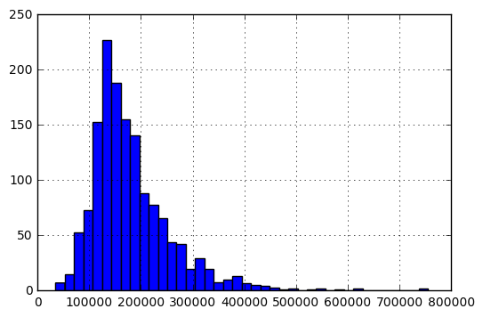

```python
df_train['SalePrice'].hist(bins = 40)
plt.show()
```

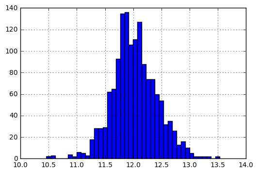

```python
df_train["SalePrice"] = np.log1p(df_train["SalePrice"])
df_train['SalePrice'].hist(bins = 40)
plt.show()
```

# Explanatory variables

## All variables compleatness

```python
df_nulls=pd.DataFrame(df_train.isnull().sum(), columns=['nulls'])
df_nulls['nulls_pcnt']=round(df_nulls['nulls']/len(df_train),2)*100
df_nulls
```

|  | nulls | nulls_pcnt |
| --- | --- | --- |
| 1stFlrSF | 0 | 0.0 |
| 2ndFlrSF | 0 | 0.0 |
| 3SsnPorch | 0 | 0.0 |
| Alley | 1369 | 94.0 |
| BedroomAbvGr | 0 | 0.0 |
| BldgType | 0 | 0.0 |
| BsmtCond | 37 | 3.0 |
| BsmtExposure | 38 | 3.0 |
| BsmtFinSF1 | 0 | 0.0 |
| BsmtFinSF2 | 0 | 0.0 |
| BsmtFinType1 | 37 | 3.0 |
| BsmtFinType2 | 38 | 3.0 |
| BsmtFullBath | 0 | 0.0 |
| BsmtHalfBath | 0 | 0.0 |
| BsmtQual | 37 | 3.0 |
| BsmtUnfSF | 0 | 0.0 |
| CentralAir | 0 | 0.0 |
| Condition1 | 0 | 0.0 |
| Condition2 | 0 | 0.0 |
| Electrical | 1 | 0.0 |
| EnclosedPorch | 0 | 0.0 |
| ExterCond | 0 | 0.0 |
| ExterQual | 0 | 0.0 |
| Exterior1st | 0 | 0.0 |
| Exterior2nd | 0 | 0.0 |
| Fence | 1179 | 81.0 |
| FireplaceQu | 690 | 47.0 |
| Fireplaces | 0 | 0.0 |
| Foundation | 0 | 0.0 |
| FullBath | 0 | 0.0 |
| Functional | 0 | 0.0 |
| GarageArea | 0 | 0.0 |
| GarageCars | 0 | 0.0 |
| GarageCond | 81 | 6.0 |
| GarageFinish | 81 | 6.0 |
| GarageQual | 81 | 6.0 |
| GarageType | 81 | 6.0 |
| GarageYrBlt | 81 | 6.0 |
| GrLivArea | 0 | 0.0 |
| HalfBath | 0 | 0.0 |
| Heating | 0 | 0.0 |
| HeatingQC | 0 | 0.0 |
| HouseStyle | 0 | 0.0 |
| KitchenAbvGr | 0 | 0.0 |
| KitchenQual | 0 | 0.0 |
| LandContour | 0 | 0.0 |
| LandSlope | 0 | 0.0 |
| LotArea | 0 | 0.0 |
| LotConfig | 0 | 0.0 |
| LotFrontage | 259 | 18.0 |
| LotShape | 0 | 0.0 |
| LowQualFinSF | 0 | 0.0 |
| MSSubClass | 0 | 0.0 |
| MSZoning | 0 | 0.0 |
| MasVnrArea | 8 | 1.0 |
| MasVnrType | 8 | 1.0 |
| MiscFeature | 1406 | 96.0 |
| MiscVal | 0 | 0.0 |
| Neighborhood | 0 | 0.0 |
| OpenPorchSF | 0 | 0.0 |
| OverallCond | 0 | 0.0 |
| OverallQual | 0 | 0.0 |
| PavedDrive | 0 | 0.0 |
| PoolArea | 0 | 0.0 |
| PoolQC | 1453 | 100.0 |
| RoofMatl | 0 | 0.0 |
| RoofStyle | 0 | 0.0 |
| SaleCondition | 0 | 0.0 |
| SalePrice | 0 | 0.0 |
| SaleType | 0 | 0.0 |
| ScreenPorch | 0 | 0.0 |
| Street | 0 | 0.0 |
| TotRmsAbvGrd | 0 | 0.0 |
| TotalBsmtSF | 0 | 0.0 |
| Utilities | 0 | 0.0 |
| WoodDeckSF | 0 | 0.0 |
| YearBuilt | 0 | 0.0 |
| YearRemodAdd | 0 | 0.0 |
| YearsBuilt | 0 | 0.0 |

The following variables should be discarded by compleatness:

Alley

Fence

MiscFeature

PoolQC

```python
df_train=df_train.drop(["Alley","Fence","MiscFeature","PoolQC"],axis=1)
```

```python
df_types=pd.DataFrame(df_train.dtypes, columns=['type'])
list_categorical=df_types[df_types.type=='object'].reset_index()['index'].tolist()
list_continuous=df_types[df_types.type!='object'].reset_index()['index'].tolist()
```

### Missing values treatment

```python
df_nulls=df_nulls.drop(["Alley","Fence","MiscFeature","PoolQC"],axis=0)
df_nt=df_nulls.join(df_types)

list_missing_cate=df_nt[(df_nt.nulls_pcnt>0) & (df_nt.type=='object')].index
print(list(list_missing_cate))

list_missing_cont=df_nt[(df_nt.nulls_pcnt>0) & (df_nt.type!='object')].index
print(list(list_missing_cont))
```

```
['BsmtCond', 'BsmtExposure', 'BsmtFinType1', 'BsmtFinType2', 'BsmtQual', 'FireplaceQu', 'GarageCond', 'GarageFinish', 'GarageQual', 'GarageType', 'MasVnrType']
['GarageYrBlt', 'LotFrontage', 'MasVnrArea']
```

#### Continuous

```python
for i in list_missing_cont:
    df_train=df_train.fillna(df_train[i].mode()[0])
```

```python
df_nulls=pd.DataFrame(df_train.isnull().sum(), columns=['nulls'])
df_nulls['nulls_pcnt']=round(df_nulls['nulls']/len(df_train),2)*100
df_nt=df_nulls.join(df_types)

list_missing_cont=df_nt[(df_nt.nulls_pcnt>0) & (df_nt.type!='object')].index
print(list(list_missing_cont))
```

```
[]
```

#### Categorical

```python
for i in list_missing_cate:
    df_train=df_train.fillna('Empty')
```

```python
df_nulls=pd.DataFrame(df_train.isnull().sum(), columns=['nulls'])
df_nulls['nulls_pcnt']=round(df_nulls['nulls']/len(df_train),2)*100
df_nt=df_nulls.join(df_types)

list_missing_cate=df_nt[(df_nt.nulls_pcnt>0) & (df_nt.type=='object')].index
print(list(list_missing_cont))
```

```
[]
```

## Correlation

```python
y=df_train#.SalePrice
list_corr=df_train.drop(list_categorical,axis=1).drop(["SalePrice"], axis=1).apply(lambda x: x.corr(y.SalePrice))
df_train.corr()#.style.background_gradient(cmap='coolwarm').set_precision(2)
```

|  | 1stFlrSF | 2ndFlrSF | 3SsnPorch | BedroomAbvGr | BsmtFinSF1 | BsmtFinSF2 | BsmtFullBath | BsmtHalfBath | BsmtUnfSF | EnclosedPorch | Fireplaces | FullBath | GarageArea | GarageCars | GarageYrBlt | GrLivArea | HalfBath | KitchenAbvGr | LotArea | LotFrontage | LowQualFinSF | MSSubClass | MasVnrArea | MiscVal | OpenPorchSF | OverallCond | OverallQual | PoolArea | SalePrice | … |
| --- | --- | --- | --- | --- | --- | --- | --- | --- | --- | --- | --- | --- | --- | --- | --- | --- | --- | --- | --- | --- | --- | --- | --- | --- | --- | --- | --- | --- | --- | --- |
| 1stFlrSF | 1.000000 | -0.202646 | 0.056104 | 0.127401 | 0.445863 | 0.097117 | 0.244671 | 0.001956 | 0.317987 | -0.065292 | 0.410531 | 0.380637 | 0.489782 | 0.439317 | 0.182240 | 0.566024 | -0.119916 | 0.068101 | 0.299475 | 0.035664 | -0.014241 | -0.251758 | 0.299131 | -0.021096 | 0.211671 | -0.144203 | 0.476224 | 0.131525 | 0.596981 | … |
| 2ndFlrSF | -0.202646 | 1.000000 | -0.024358 | 0.502901 | -0.137079 | -0.099260 | -0.169494 | -0.023855 | 0.004469 | 0.061989 | 0.194561 | 0.421378 | 0.138347 | 0.183926 | 0.052291 | 0.687501 | 0.609707 | 0.059306 | 0.050986 | 0.006692 | 0.063353 | 0.307886 | 0.138291 | 0.016197 | 0.208026 | 0.028942 | 0.295493 | 0.081487 | 0.319300 | … |
| 3SsnPorch | 0.056104 | -0.024358 | 1.000000 | -0.024478 | 0.026451 | -0.029993 | -0.000106 | 0.035114 | 0.020764 | -0.037305 | 0.011257 | 0.035353 | 0.035087 | 0.035765 | 0.015905 | 0.020643 | -0.004972 | -0.024600 | 0.020423 | 0.022704 | -0.004296 | -0.043825 | 0.009537 | 0.000354 | -0.005842 | 0.025504 | 0.030371 | -0.007992 | 0.054900 | … |
| BedroomAbvGr | 0.127401 | 0.502901 | -0.024478 | 1.000000 | -0.107355 | -0.015728 | -0.150673 | 0.046519 | 0.166643 | 0.041570 | 0.107570 | 0.363252 | 0.065253 | 0.086106 | -0.056782 | 0.521270 | 0.226651 | 0.198597 | 0.119690 | 0.014952 | 0.105607 | -0.023438 | 0.074346 | 0.007767 | 0.093810 | 0.012980 | 0.101676 | 0.070703 | 0.209043 | … |
| BsmtFinSF1 | 0.445863 | -0.137079 | 0.026451 | -0.107355 | 1.000000 | -0.050117 | 0.649212 | 0.067418 | -0.495251 | -0.102303 | 0.260011 | 0.058543 | 0.296970 | 0.224054 | 0.119267 | 0.208171 | 0.004262 | -0.081007 | 0.214103 | 0.084681 | -0.064503 | -0.069836 | 0.238359 | 0.003571 | 0.111761 | -0.046231 | 0.239666 | 0.140491 | 0.372023 | … |
| BsmtFinSF2 | 0.097117 | -0.099260 | -0.029993 | -0.015728 | -0.050117 | 1.000000 | 0.158678 | 0.070948 | -0.209294 | 0.036543 | 0.046921 | -0.076444 | -0.018227 | -0.038264 | -0.094208 | -0.009640 | -0.032148 | -0.040751 | 0.111170 | 0.048986 | 0.014807 | -0.065649 | -0.070230 | 0.004940 | 0.003093 | 0.040229 | -0.059119 | 0.041709 | 0.004832 | … |
| BsmtFullBath | 0.244671 | -0.169494 | -0.000106 | -0.150673 | 0.649212 | 0.158678 | 1.000000 | -0.147871 | -0.422900 | -0.049911 | 0.137928 | -0.064512 | 0.179189 | 0.131881 | 0.105716 | 0.034836 | -0.030905 | -0.041503 | 0.158155 | 0.064347 | -0.047143 | 0.003491 | 0.095661 | -0.023047 | 0.067341 | -0.054942 | 0.111098 | 0.067616 | 0.236224 | … |
| BsmtHalfBath | 0.001956 | -0.023855 | 0.035114 | 0.046519 | 0.067418 | 0.070948 | -0.147871 | 1.000000 | -0.095804 | -0.008555 | 0.028976 | -0.054536 | -0.024536 | -0.020891 | -0.077945 | -0.018918 | -0.012340 | -0.037944 | 0.048046 | 0.030586 | -0.005842 | -0.002333 | 0.010070 | -0.007367 | -0.025324 | 0.117821 | -0.040150 | 0.020025 | -0.005149 | … |
| BsmtUnfSF | 0.317987 | 0.004469 | 0.020764 | 0.166643 | -0.495251 | -0.209294 | -0.422900 | -0.095804 | 1.000000 | -0.002538 | 0.051575 | 0.288886 | 0.183303 | 0.214175 | 0.172350 | 0.240257 | -0.041118 | 0.030086 | -0.002618 | -0.104079 | 0.028167 | -0.140759 | 0.093313 | -0.023837 | 0.129005 | -0.136841 | 0.308159 | -0.035092 | 0.221985 | … |
| EnclosedPorch | -0.065292 | 0.061989 | -0.037305 | 0.041570 | -0.102303 | 0.036543 | -0.049911 | -0.008555 | -0.002538 | 1.000000 | -0.024822 | -0.115093 | -0.121777 | -0.151434 | -0.262014 | 0.009113 | -0.095317 | 0.037312 | -0.018340 | -0.027080 | 0.061081 | -0.012037 | -0.084447 | 0.018361 | -0.093079 | 0.070356 | -0.113937 | 0.054203 | -0.149050 | … |
| Fireplaces | 0.410531 | 0.194561 | 0.011257 | 0.107570 | 0.260011 | 0.046921 | 0.137928 | 0.028976 | 0.051575 | -0.024822 | 1.000000 | 0.243671 | 0.269141 | 0.300789 | -0.000926 | 0.461679 | 0.203649 | -0.123936 | 0.271364 | 0.143926 | -0.021272 | -0.045569 | 0.205391 | 0.001409 | 0.169405 | -0.023820 | 0.396765 | 0.095074 | 0.489450 | … |
| FullBath | 0.380637 | 0.421378 | 0.035353 | 0.363252 | 0.058543 | -0.076444 | -0.064512 | -0.054536 | 0.288886 | -0.115093 | 0.243671 | 1.000000 | 0.405656 | 0.469672 | 0.426511 | 0.630012 | 0.136381 | 0.133115 | 0.126031 | -0.002285 | -0.000710 | 0.131608 | 0.253654 | -0.014290 | 0.259977 | -0.194149 | 0.550600 | 0.049604 | 0.594771 | … |
| GarageArea | 0.489782 | 0.138347 | 0.035087 | 0.065253 | 0.296970 | -0.018227 | 0.179189 | -0.024536 | 0.183303 | -0.121777 | 0.269141 | 0.405656 | 1.000000 | 0.882475 | 0.330489 | 0.468997 | 0.163549 | -0.064433 | 0.180403 | 0.015029 | -0.067601 | -0.098672 | 0.313654 | -0.027400 | 0.241435 | -0.151521 | 0.562022 | 0.061047 | 0.650888 | … |
| GarageCars | 0.439317 | 0.183926 | 0.035765 | 0.086106 | 0.224054 | -0.038264 | 0.131881 | -0.020891 | 0.214175 | -0.151434 | 0.300789 | 0.469672 | 0.882475 | 1.000000 | 0.327283 | 0.467247 | 0.219178 | -0.050634 | 0.154871 | 0.015983 | -0.094480 | -0.040110 | 0.309006 | -0.043080 | 0.213569 | -0.185758 | 0.600671 | 0.020934 | 0.680625 | … |
| GarageYrBlt | 0.182240 | 0.052291 | 0.015905 | -0.056782 | 0.119267 | -0.094208 | 0.105716 | -0.077945 | 0.172350 | -0.262014 | -0.000926 | 0.426511 | 0.330489 | 0.327283 | 1.000000 | 0.178186 | 0.158951 | -0.066911 | -0.042198 | -0.016004 | 0.007298 | 0.098664 | 0.206440 | -0.029658 | 0.202417 | -0.299203 | 0.437998 | -0.018137 | 0.406004 | … |
| GrLivArea | 0.566024 | 0.687501 | 0.020643 | 0.521270 | 0.208171 | -0.009640 | 0.034836 | -0.018918 | 0.240257 | 0.009113 | 0.461679 | 0.630012 | 0.468997 | 0.467247 | 0.178186 | 1.000000 | 0.415772 | 0.100063 | 0.263116 | 0.028716 | 0.134683 | 0.074853 | 0.329396 | -0.002416 | 0.330224 | -0.079686 | 0.593007 | 0.170205 | 0.700927 | … |
| HalfBath | -0.119916 | 0.609707 | -0.004972 | 0.226651 | 0.004262 | -0.032148 | -0.030905 | -0.012340 | -0.041118 | -0.095317 | 0.203649 | 0.136381 | 0.163549 | 0.219178 | 0.158951 | 0.415772 | 1.000000 | -0.068263 | 0.014259 | 0.057889 | -0.027080 | 0.177354 | 0.180465 | 0.001290 | 0.199740 | -0.060769 | 0.273458 | 0.022381 | 0.313982 | … |
| KitchenAbvGr | 0.068101 | 0.059306 | -0.024600 | 0.198597 | -0.081007 | -0.040751 | -0.041503 | -0.037944 | 0.030086 | 0.037312 | -0.123936 | 0.133115 | -0.064433 | -0.050634 | -0.066911 | 0.100063 | -0.068263 | 1.000000 | -0.017784 | -0.049505 | 0.007522 | 0.281721 | -0.013274 | 0.062341 | -0.070091 | -0.087001 | -0.183882 | -0.014525 | -0.147548 | … |
| LotArea | 0.299475 | 0.050986 | 0.020423 | 0.119690 | 0.214103 | 0.111170 | 0.158155 | 0.048046 | -0.002618 | -0.018340 | 0.271364 | 0.126031 | 0.180403 | 0.154871 | -0.042198 | 0.263116 | 0.014259 | -0.017784 | 1.000000 | 0.131044 | 0.004779 | -0.139781 | 0.089987 | 0.038068 | 0.084774 | -0.005636 | 0.105806 | 0.077672 | 0.257320 | … |
| LotFrontage | 0.035664 | 0.006692 | 0.022704 | 0.014952 | 0.084681 | 0.048986 | 0.064347 | 0.030586 | -0.104079 | -0.027080 | 0.143926 | -0.002285 | 0.015029 | 0.015983 | -0.016004 | 0.028716 | 0.057889 | -0.049505 | 0.131044 | 1.000000 | -0.033294 | -0.025947 | 0.022245 | 0.078149 | 0.027038 | 0.024183 | -0.028965 | 0.006431 | 0.054372 | … |
| LowQualFinSF | -0.014241 | 0.063353 | -0.004296 | 0.105607 | -0.064503 | 0.014807 | -0.047143 | -0.005842 | 0.028167 | 0.061081 | -0.021272 | -0.000710 | -0.067601 | -0.094480 | 0.007298 | 0.134683 | -0.027080 | 0.007522 | 0.004779 | -0.033294 | 1.000000 | 0.046474 | -0.060003 | -0.003793 | 0.018251 | 0.025494 | -0.030429 | 0.062157 | -0.037963 | … |
| MSSubClass | -0.251758 | 0.307886 | -0.043825 | -0.023438 | -0.069836 | -0.065649 | 0.003491 | -0.002333 | -0.140759 | -0.012037 | -0.045569 | 0.131608 | -0.098672 | -0.040110 | 0.098664 | 0.074853 | 0.177354 | 0.281721 | -0.139781 | -0.025947 | 0.046474 | 1.000000 | 0.007948 | -0.007683 | -0.006100 | -0.059316 | 0.032628 | 0.008283 | -0.073959 | … |
| MasVnrArea | 0.299131 | 0.138291 | 0.009537 | 0.074346 | 0.238359 | -0.070230 | 0.095661 | 0.010070 | 0.093313 | -0.084447 | 0.205391 | 0.253654 | 0.313654 | 0.309006 | 0.206440 | 0.329396 | 0.180465 | -0.013274 | 0.089987 | 0.022245 | -0.060003 | 0.007948 | 1.000000 | -0.027532 | 0.132336 | -0.129565 | 0.361778 | 0.006125 | 0.373433 | … |
| MiscVal | -0.021096 | 0.016197 | 0.000354 | 0.007767 | 0.003571 | 0.004940 | -0.023047 | -0.007367 | -0.023837 | 0.018361 | 0.001409 | -0.014290 | -0.027400 | -0.043080 | -0.029658 | -0.002416 | 0.001290 | 0.062341 | 0.038068 | 0.078149 | -0.003793 | -0.007683 | -0.027532 | 1.000000 | -0.018584 | 0.068777 | -0.031406 | 0.029669 | -0.020021 | … |
| OpenPorchSF | 0.211671 | 0.208026 | -0.005842 | 0.093810 | 0.111761 | 0.003093 | 0.067341 | -0.025324 | 0.129005 | -0.093079 | 0.169405 | 0.259977 | 0.241435 | 0.213569 | 0.202417 | 0.330224 | 0.199740 | -0.070091 | 0.084774 | 0.027038 | 0.018251 | -0.006100 | 0.132336 | -0.018584 | 1.000000 | -0.032589 | 0.308819 | 0.060762 | 0.321053 | … |
| OverallCond | -0.144203 | 0.028942 | 0.025504 | 0.012980 | -0.046231 | 0.040229 | -0.054942 | 0.117821 | -0.136841 | 0.070356 | -0.023820 | -0.194149 | -0.151521 | -0.185758 | -0.299203 | -0.079686 | -0.060769 | -0.087001 | -0.005636 | 0.024183 | 0.025494 | -0.059316 | -0.129565 | 0.068777 | -0.032589 | 1.000000 | -0.091932 | -0.001985 | -0.036868 | … |
| OverallQual | 0.476224 | 0.295493 | 0.030371 | 0.101676 | 0.239666 | -0.059119 | 0.111098 | -0.040150 | 0.308159 | -0.113937 | 0.396765 | 0.550600 | 0.562022 | 0.600671 | 0.437998 | 0.593007 | 0.273458 | -0.183882 | 0.105806 | -0.028965 | -0.030429 | 0.032628 | 0.361778 | -0.031406 | 0.308819 | -0.091932 | 1.000000 | 0.065166 | 0.817185 | … |
| PoolArea | 0.131525 | 0.081487 | -0.007992 | 0.070703 | 0.140491 | 0.041709 | 0.067616 | 0.020025 | -0.035092 | 0.054203 | 0.095074 | 0.049604 | 0.061047 | 0.020934 | -0.018137 | 0.170205 | 0.022381 | -0.014525 | 0.077672 | 0.006431 | 0.062157 | 0.008283 | 0.006125 | 0.029669 | 0.060762 | -0.001985 | 0.065166 | 1.000000 | 0.069798 | … |
| SalePrice | 0.596981 | 0.319300 | 0.054900 | 0.209043 | 0.372023 | 0.004832 | 0.236224 | -0.005149 | 0.221985 | -0.149050 | 0.489450 | 0.594771 | 0.650888 | 0.680625 | 0.406004 | 0.700927 | 0.313982 | -0.147548 | 0.257320 | 0.054372 | -0.037963 | -0.073959 | 0.373433 | -0.020021 | 0.321053 | -0.036868 | 0.817185 | 0.069798 | 1.000000 | … |
| ScreenPorch | 0.088758 | 0.040606 | -0.031436 | 0.044300 | 0.062021 | 0.088871 | 0.023148 | 0.032121 | -0.012579 | -0.082864 | 0.184530 | -0.008106 | 0.051412 | 0.050494 | -0.089013 | 0.101510 | 0.072426 | -0.051613 | 0.043160 | 0.002383 | 0.026799 | -0.026030 | 0.036202 | 0.031946 | 0.074304 | 0.054811 | 0.064886 | 0.051307 | 0.121208 | … |
| TotRmsAbvGrd | 0.409516 | 0.616423 | -0.006683 | 0.676620 | 0.044316 | -0.035227 | -0.053275 | -0.023836 | 0.250647 | 0.004151 | 0.326114 | 0.554784 | 0.337822 | 0.362289 | 0.114855 | 0.825489 | 0.343415 | 0.256045 | 0.190015 | -0.013755 | 0.131185 | 0.040380 | 0.224069 | 0.024763 | 0.234192 | -0.057583 | 0.427452 | 0.083757 | 0.534422 | … |
| TotalBsmtSF | 0.819530 | -0.174512 | 0.037384 | 0.050450 | 0.522396 | 0.104810 | 0.307351 | -0.000315 | 0.415360 | -0.095478 | 0.339519 | 0.323722 | 0.486665 | 0.434585 | 0.262945 | 0.454868 | -0.048804 | -0.068901 | 0.260833 | 0.001222 | -0.033245 | -0.238518 | 0.315970 | -0.018479 | 0.247264 | -0.171098 | 0.537808 | 0.126053 | 0.612134 | … |
| WoodDeckSF | 0.235459 | 0.092165 | -0.032771 | 0.046854 | 0.204306 | 0.067898 | 0.175315 | 0.040161 | -0.005316 | -0.125989 | 0.200019 | 0.187703 | 0.224666 | 0.226342 | 0.187961 | 0.247433 | 0.108080 | -0.090130 | 0.171698 | 0.087427 | -0.025444 | -0.012579 | 0.114434 | -0.009551 | 0.058661 | -0.003334 | 0.238923 | 0.073378 | 0.334135 | … |
| YearBuilt | 0.281986 | 0.010308 | 0.031355 | -0.070651 | 0.249503 | -0.049107 | 0.187599 | -0.038162 | 0.149040 | -0.387268 | 0.147716 | 0.468271 | 0.478954 | 0.537850 | 0.700098 | 0.199010 | 0.242656 | -0.174800 | 0.014228 | 0.052510 | -0.183784 | 0.027850 | 0.289944 | -0.034383 | 0.188686 | -0.375983 | 0.572323 | 0.004950 | 0.586570 | … |
| YearRemodAdd | 0.240379 | 0.140024 | 0.045286 | -0.040581 | 0.128451 | -0.067759 | 0.119470 | -0.012337 | 0.181133 | -0.193919 | 0.112581 | 0.439046 | 0.371600 | 0.420622 | 0.571369 | 0.287389 | 0.183331 | -0.149598 | 0.013788 | -0.031337 | -0.062419 | 0.040581 | 0.177627 | -0.010286 | 0.226298 | 0.073741 | 0.550684 | 0.005829 | 0.565608 | … |
| YearsBuilt | 0.008369 | 0.022973 | -0.023893 | 0.028413 | -0.011814 | -0.029431 | -0.063405 | 0.041377 | 0.035710 | 0.014972 | 0.016402 | 0.010297 | 0.022870 | 0.032581 | -0.001847 | 0.028297 | 0.011928 | -0.036578 | 0.014205 | -0.018928 | 0.033026 | 0.023960 | 0.003318 | -0.003844 | 0.046009 | -0.043809 | 0.015494 | 0.066099 | 0.027826 | … |

```python
pd.DataFrame(list_corr,columns=['Corr']).style.background_gradient(cmap='coolwarm').set_precision(2)
```

|  | Corr |
| --- | --- |
| 1stFlrSF | 0.6 |
| 2ndFlrSF | 0.32 |
| 3SsnPorch | 0.055 |
| BedroomAbvGr | 0.21 |
| BsmtFinSF1 | 0.37 |
| BsmtFinSF2 | 0.0048 |
| BsmtFullBath | 0.24 |
| BsmtHalfBath | -0.0051 |
| BsmtUnfSF | 0.22 |
| EnclosedPorch | -0.15 |
| Fireplaces | 0.49 |
| FullBath | 0.59 |
| GarageArea | 0.65 |
| GarageCars | 0.68 |
| GarageYrBlt | 0.41 |
| GrLivArea | 0.7 |
| HalfBath | 0.31 |
| KitchenAbvGr | -0.15 |
| LotArea | 0.26 |
| LotFrontage | 0.054 |
| LowQualFinSF | -0.038 |
| MSSubClass | -0.074 |
| MasVnrArea | 0.37 |
| MiscVal | -0.02 |
| OpenPorchSF | 0.32 |
| OverallCond | -0.037 |
| OverallQual | 0.82 |
| PoolArea | 0.07 |
| ScreenPorch | 0.12 |
| TotRmsAbvGrd | 0.53 |
| TotalBsmtSF | 0.61 |
| WoodDeckSF | 0.33 |
| YearBuilt | 0.59 |
| YearRemodAdd | 0.57 |
| YearsBuilt | 0.028 |

There is correlation between some explanatory variables:

TotalBsmtSF & 1stFlrSF

TotRmsAbvGrd & GrLivArea ->

YearBuilt & GarageYrBlt

Garagearea & GarageCars ->

OverallQual & SalePrice : this is actually ok

```python
df_train['TotalIndoorSF']=df_train['TotalBsmtSF']+df_train['1stFlrSF']+df_train['2ndFlrSF']
df_train['AvgYearBuilt_Garage']=(df_train['YearBuilt']+df_train['GarageYrBlt'])/2
df_train['NoR_and_Area']=df_train['GrLivArea']/df_train['TotRmsAbvGrd']
print(df_train.shape)
```

```
(1460, 78)
```

```python
df_train=df_train.drop(['TotalBsmtSF','1stFlrSF','2ndFlrSF','YearBuilt','GarageYrBlt','GrLivArea','TotRmsAbvGrd'],axis=1)
print(df_train.shape)
```

```
(1460, 71)
```

```python
y=df_train#.SalePrice
list_corr=df_train.drop(list_categorical,axis=1).drop(["SalePrice"], axis=1).apply(lambda x: x.corr(y.SalePrice))
#pd.DataFrame(list_corr,columns=['Corr']).style.background_gradient(cmap='coolwarm').set_precision(2)
```

```python
df_train.describe()
```

|  | 3SsnPorch | BedroomAbvGr | BsmtFinSF1 | BsmtFinSF2 | BsmtFullBath | BsmtHalfBath | BsmtUnfSF | EnclosedPorch | Fireplaces | FullBath | GarageArea | GarageCars | HalfBath | KitchenAbvGr | LotArea | LotFrontage | LowQualFinSF | MSSubClass | MasVnrArea | MiscVal | OpenPorchSF | OverallCond | OverallQual | PoolArea | SalePrice | ScreenPorch | WoodDeckSF | YearRemodAdd | YearsBuilt | … |
| --- | --- | --- | --- | --- | --- | --- | --- | --- | --- | --- | --- | --- | --- | --- | --- | --- | --- | --- | --- | --- | --- | --- | --- | --- | --- | --- | --- | --- | --- | --- |
| count | 1460.000000 | 1460.000000 | 1460.000000 | 1460.000000 | 1460.000000 | 1460.000000 | 1460.000000 | 1460.000000 | 1460.000000 | 1460.000000 | 1460.000000 | 1460.000000 | 1460.000000 | 1460.000000 | 1460.000000 | 1460.000000 | 1460.000000 | 1460.000000 | 1460.000000 | 1460.000000 | 1460.000000 | 1460.000000 | 1460.000000 | 1460.000000 | 1460.000000 | 1460.000000 | 1460.000000 | 1460.000000 | 1460.000000 | … |
| mean | 3.409589 | 2.866438 | 443.639726 | 46.549315 | 0.425342 | 0.057534 | 567.240411 | 21.954110 | 0.613014 | 1.565068 | 472.980137 | 1.767123 | 0.382877 | 1.046575 | 10516.828082 | 413.304795 | 5.844521 | 56.897260 | 114.103425 | 43.489041 | 46.660274 | 5.575342 | 6.099315 | 2.758904 | 12.024057 | 15.060959 | 94.244521 | 1984.865753 | 3.657420 | … |
| std | 29.317331 | 0.815778 | 456.098091 | 161.319273 | 0.518911 | 0.238753 | 441.866955 | 61.119149 | 0.644666 | 0.550916 | 213.804841 | 0.747315 | 0.502885 | 0.220338 | 9981.264932 | 739.740906 | 48.623081 | 42.300571 | 228.732104 | 496.123024 | 66.256028 | 1.112799 | 1.382997 | 40.177307 | 0.399449 | 55.757415 | 125.338794 | 20.645407 | 1.314303 | … |
| min | 0.000000 | 0.000000 | 0.000000 | 0.000000 | 0.000000 | 0.000000 | 0.000000 | 0.000000 | 0.000000 | 0.000000 | 0.000000 | 0.000000 | 0.000000 | 0.000000 | 1300.000000 | 21.000000 | 0.000000 | 20.000000 | 0.000000 | 0.000000 | 0.000000 | 1.000000 | 1.000000 | 0.000000 | 10.460271 | 0.000000 | 0.000000 | 1950.000000 | 1.416667 | … |
| 25% | 0.000000 | 2.000000 | 0.000000 | 0.000000 | 0.000000 | 0.000000 | 223.000000 | 0.000000 | 0.000000 | 1.000000 | 334.500000 | 1.000000 | 0.000000 | 1.000000 | 7553.500000 | 60.000000 | 0.000000 | 20.000000 | 0.000000 | 0.000000 | 0.000000 | 5.000000 | 5.000000 | 0.000000 | 11.775105 | 0.000000 | 0.000000 | 1967.000000 | 2.500000 | … |
| 50% | 0.000000 | 3.000000 | 383.500000 | 0.000000 | 0.000000 | 0.000000 | 477.500000 | 0.000000 | 1.000000 | 2.000000 | 480.000000 | 2.000000 | 0.000000 | 1.000000 | 9478.500000 | 74.000000 | 0.000000 | 50.000000 | 0.000000 | 0.000000 | 25.000000 | 5.000000 | 6.000000 | 0.000000 | 12.001512 | 0.000000 | 0.000000 | 1994.000000 | 3.583333 | … |
| 75% | 0.000000 | 3.000000 | 712.250000 | 0.000000 | 1.000000 | 0.000000 | 808.000000 | 0.000000 | 1.000000 | 2.000000 | 576.000000 | 2.000000 | 1.000000 | 1.000000 | 11601.500000 | 98.000000 | 0.000000 | 70.000000 | 168.000000 | 0.000000 | 68.000000 | 6.000000 | 7.000000 | 0.000000 | 12.273736 | 0.000000 | 168.000000 | 2004.000000 | 4.666667 | … |
| max | 508.000000 | 8.000000 | 5644.000000 | 1474.000000 | 3.000000 | 2.000000 | 2336.000000 | 552.000000 | 3.000000 | 3.000000 | 1418.000000 | 4.000000 | 2.000000 | 3.000000 | 215245.000000 | 2005.000000 | 572.000000 | 190.000000 | 2005.000000 | 15500.000000 | 547.000000 | 9.000000 | 10.000000 | 738.000000 | 13.534474 | 480.000000 | 857.000000 | 2010.000000 | 5.916667 | … |

# Categorical

## Box Plots

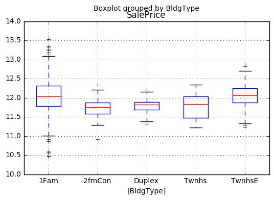

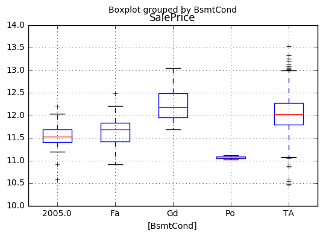

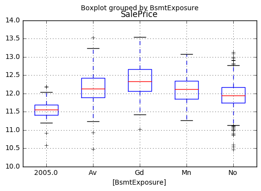

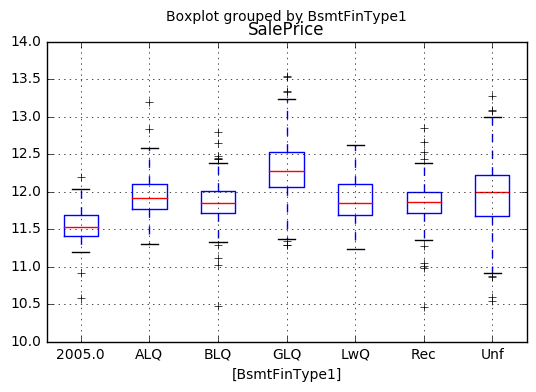

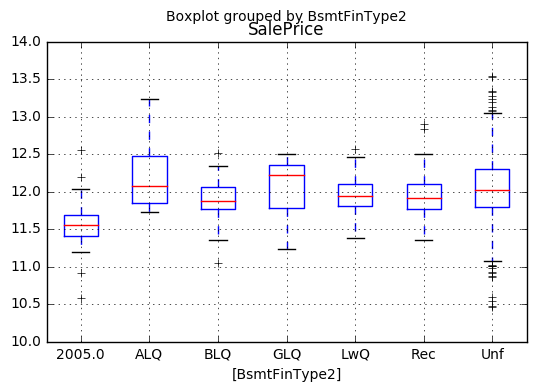

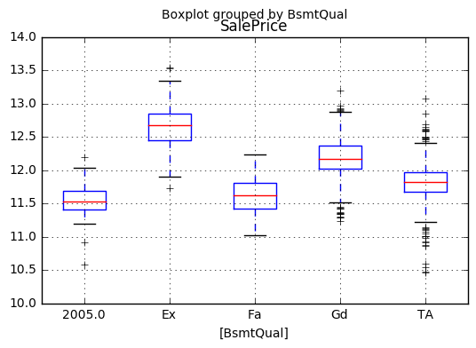

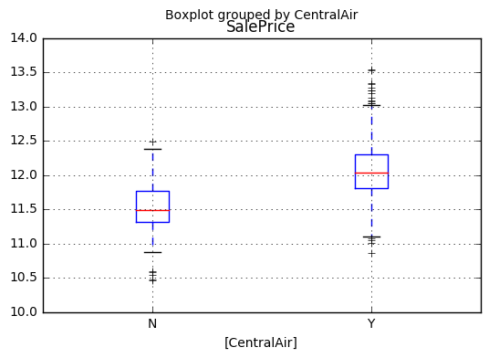

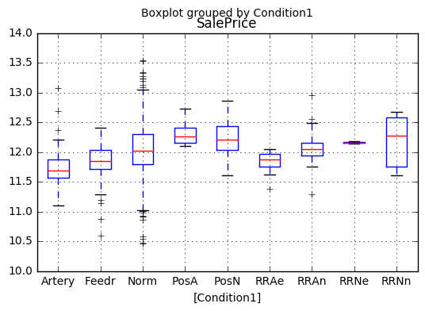

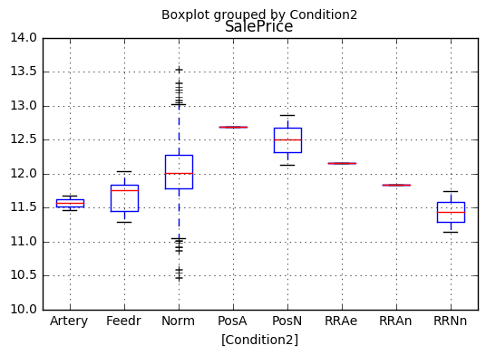

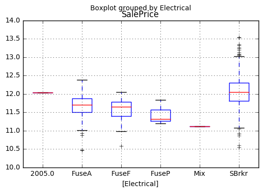

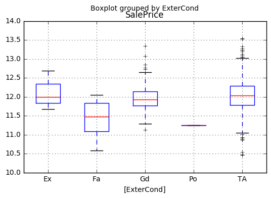

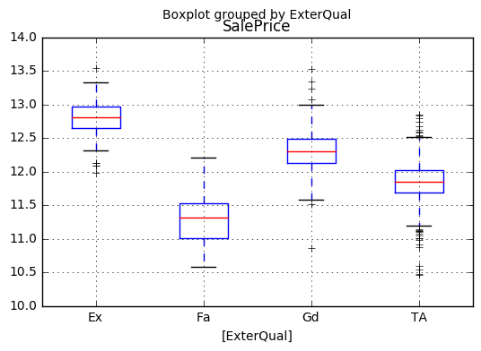

[27 more figures not shown]

```python
for i in list_categorical:
    df_train[['SalePrice',i]].boxplot(by=i)
    plt.show()
```

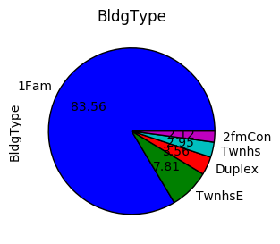

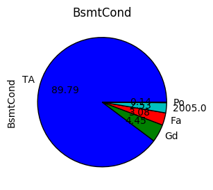

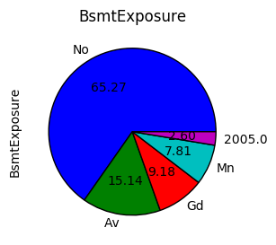

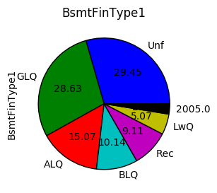

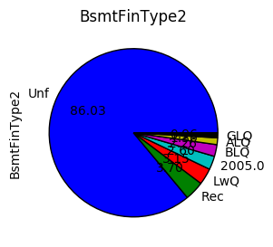

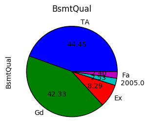

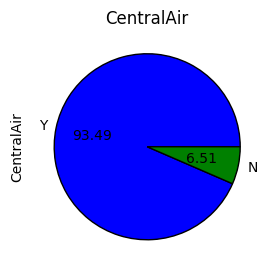

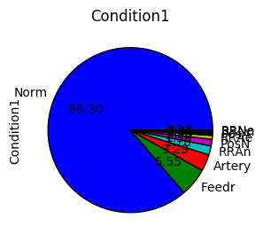

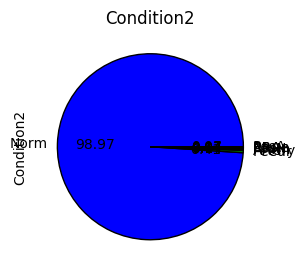

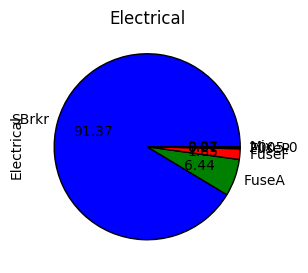

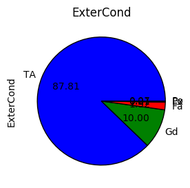

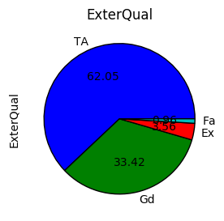

[27 more figures not shown]

```python
for i in (list_categorical):
    plot = df_train[i].value_counts().plot(kind='pie', autopct='%.2f',
                                            figsize=(3, 3),
                                            title=i)
    plt.show()
```

By this analysis the following variables should be removed:

```
Utilities
```

## To dummy transformation

Remove the redundant variables when transforming is important

```python
df_train2=pd.get_dummies(df_train[list_categorical],drop_first=True)
print(df_train.shape)
```

```
(1460, 71)
```

```python
df_train=df_train.drop(list_categorical, axis=1)

print(df_train.shape)
```

```
(1460, 32)
```

```python
print(df_train2.shape)
df_train2.describe()
#df_train2.head()
```

```
(1460, 212)
```

|  | BldgType_2fmCon | BldgType_Duplex | BldgType_Twnhs | BldgType_TwnhsE | BsmtCond_Fa | BsmtCond_Gd | BsmtCond_Po | BsmtCond_TA | BsmtExposure_Av | BsmtExposure_Gd | BsmtExposure_Mn | BsmtExposure_No | BsmtFinType1_ALQ | BsmtFinType1_BLQ | BsmtFinType1_GLQ | BsmtFinType1_LwQ | BsmtFinType1_Rec | BsmtFinType1_Unf | BsmtFinType2_ALQ | BsmtFinType2_BLQ | BsmtFinType2_GLQ | BsmtFinType2_LwQ | BsmtFinType2_Rec | BsmtFinType2_Unf | BsmtQual_Ex | BsmtQual_Fa | BsmtQual_Gd | BsmtQual_TA | CentralAir_Y | … |
| --- | --- | --- | --- | --- | --- | --- | --- | --- | --- | --- | --- | --- | --- | --- | --- | --- | --- | --- | --- | --- | --- | --- | --- | --- | --- | --- | --- | --- | --- | --- |
| count | 1460.000000 | 1460.000000 | 1460.000000 | 1460.000000 | 1460.000000 | 1460.000000 | 1460.000000 | 1460.000000 | 1460.000000 | 1460.000000 | 1460.000000 | 1460.000000 | 1460.000000 | 1460.000000 | 1460.000000 | 1460.000000 | 1460.000000 | 1460.000000 | 1460.000000 | 1460.000000 | 1460.000000 | 1460.000000 | 1460.000000 | 1460.000000 | 1460.000000 | 1460.000000 | 1460.000000 | 1460.000000 | 1460.000000 | … |
| mean | 0.021233 | 0.035616 | 0.029452 | 0.078082 | 0.030822 | 0.044521 | 0.001370 | 0.897945 | 0.151370 | 0.091781 | 0.078082 | 0.652740 | 0.150685 | 0.101370 | 0.286301 | 0.050685 | 0.091096 | 0.294521 | 0.013014 | 0.022603 | 0.009589 | 0.031507 | 0.036986 | 0.860274 | 0.082877 | 0.023973 | 0.423288 | 0.444521 | 0.934932 | … |
| std | 0.144209 | 0.185395 | 0.169128 | 0.268393 | 0.172894 | 0.206319 | 0.036999 | 0.302824 | 0.358532 | 0.288815 | 0.268393 | 0.476262 | 0.357864 | 0.301921 | 0.452187 | 0.219429 | 0.287844 | 0.455983 | 0.113372 | 0.148684 | 0.097486 | 0.174743 | 0.188793 | 0.346821 | 0.275790 | 0.153016 | 0.494249 | 0.497083 | 0.246731 | … |
| min | 0.000000 | 0.000000 | 0.000000 | 0.000000 | 0.000000 | 0.000000 | 0.000000 | 0.000000 | 0.000000 | 0.000000 | 0.000000 | 0.000000 | 0.000000 | 0.000000 | 0.000000 | 0.000000 | 0.000000 | 0.000000 | 0.000000 | 0.000000 | 0.000000 | 0.000000 | 0.000000 | 0.000000 | 0.000000 | 0.000000 | 0.000000 | 0.000000 | 0.000000 | … |
| 25% | 0.000000 | 0.000000 | 0.000000 | 0.000000 | 0.000000 | 0.000000 | 0.000000 | 1.000000 | 0.000000 | 0.000000 | 0.000000 | 0.000000 | 0.000000 | 0.000000 | 0.000000 | 0.000000 | 0.000000 | 0.000000 | 0.000000 | 0.000000 | 0.000000 | 0.000000 | 0.000000 | 1.000000 | 0.000000 | 0.000000 | 0.000000 | 0.000000 | 1.000000 | … |
| 50% | 0.000000 | 0.000000 | 0.000000 | 0.000000 | 0.000000 | 0.000000 | 0.000000 | 1.000000 | 0.000000 | 0.000000 | 0.000000 | 1.000000 | 0.000000 | 0.000000 | 0.000000 | 0.000000 | 0.000000 | 0.000000 | 0.000000 | 0.000000 | 0.000000 | 0.000000 | 0.000000 | 1.000000 | 0.000000 | 0.000000 | 0.000000 | 0.000000 | 1.000000 | … |
| 75% | 0.000000 | 0.000000 | 0.000000 | 0.000000 | 0.000000 | 0.000000 | 0.000000 | 1.000000 | 0.000000 | 0.000000 | 0.000000 | 1.000000 | 0.000000 | 0.000000 | 1.000000 | 0.000000 | 0.000000 | 1.000000 | 0.000000 | 0.000000 | 0.000000 | 0.000000 | 0.000000 | 1.000000 | 0.000000 | 0.000000 | 1.000000 | 1.000000 | 1.000000 | … |
| max | 1.000000 | 1.000000 | 1.000000 | 1.000000 | 1.000000 | 1.000000 | 1.000000 | 1.000000 | 1.000000 | 1.000000 | 1.000000 | 1.000000 | 1.000000 | 1.000000 | 1.000000 | 1.000000 | 1.000000 | 1.000000 | 1.000000 | 1.000000 | 1.000000 | 1.000000 | 1.000000 | 1.000000 | 1.000000 | 1.000000 | 1.000000 | 1.000000 | 1.000000 | … |

```python
df_train_def=df_train.join(df_train2)
df_train_def.shape
```

```
(1460, 244)
```

# Model

```python
#X_train, X_validation, Y_train, Y_validation = train_test_split(X,Y,test_size=0.2,random_state=123)
```

```python
from sklearn.model_selection import train_test_split

train, validate = train_test_split(df_train_def, test_size=0.2)

print(train.shape)
print(validate.shape)
```

```
(1168, 244)
(292, 244)
```

```python
y_train=list(train['SalePrice'])
x_train=train.drop('SalePrice',axis=1)

y_validate=list(validate['SalePrice'])
x_validate=validate.drop('SalePrice',axis=1)

x_validate.head()
```

|  | 3SsnPorch | BedroomAbvGr | BsmtFinSF1 | BsmtFinSF2 | BsmtFullBath | BsmtHalfBath | BsmtUnfSF | EnclosedPorch | Fireplaces | FullBath | GarageArea | GarageCars | HalfBath | KitchenAbvGr | LotArea | LotFrontage | LowQualFinSF | MSSubClass | MasVnrArea | MiscVal | OpenPorchSF | OverallCond | OverallQual | PoolArea | ScreenPorch | WoodDeckSF | YearRemodAdd | YearsBuilt | TotalIndoorSF | … |
| --- | --- | --- | --- | --- | --- | --- | --- | --- | --- | --- | --- | --- | --- | --- | --- | --- | --- | --- | --- | --- | --- | --- | --- | --- | --- | --- | --- | --- | --- | --- |
| 201 | 0 | 3 | 641 | 279 | 0 | 1 | 276 | 0 | 2 | 2 | 473 | 2 | 0 | 1 | 10125 | 75.0 | 0 | 20 | 0.0 | 0 | 83 | 6 | 6 | 0 | 0 | 238 | 1977 | 3.833333 | 2475 | … |
| 239 | 0 | 3 | 94 | 0 | 0 | 0 | 641 | 0 | 1 | 1 | 220 | 1 | 1 | 1 | 8741 | 52.0 | 0 | 50 | 0.0 | 0 | 140 | 4 | 6 | 0 | 0 | 0 | 1950 | 1.666667 | 2222 | … |
| 636 | 0 | 1 | 0 | 0 | 0 | 0 | 264 | 0 | 1 | 1 | 0 | 0 | 0 | 1 | 6120 | 51.0 | 0 | 30 | 0.0 | 0 | 0 | 3 | 2 | 0 | 0 | 0 | 1950 | 2.916667 | 1064 | … |
| 1238 | 0 | 3 | 0 | 0 | 0 | 0 | 1141 | 0 | 0 | 1 | 484 | 2 | 1 | 1 | 13072 | 63.0 | 0 | 20 | 0.0 | 0 | 0 | 5 | 6 | 0 | 0 | 0 | 2005 | 5.750000 | 2282 | … |
| 740 | 0 | 2 | 0 | 0 | 0 | 0 | 264 | 112 | 0 | 2 | 360 | 2 | 0 | 1 | 9600 | 60.0 | 0 | 70 | 0.0 | 0 | 0 | 7 | 5 | 0 | 0 | 270 | 2002 | 4.583333 | 1696 | … |

```python
x_train.iloc[:len(x_train)-1,:].head()
```

|  | 3SsnPorch | BedroomAbvGr | BsmtFinSF1 | BsmtFinSF2 | BsmtFullBath | BsmtHalfBath | BsmtUnfSF | EnclosedPorch | Fireplaces | FullBath | GarageArea | GarageCars | HalfBath | KitchenAbvGr | LotArea | LotFrontage | LowQualFinSF | MSSubClass | MasVnrArea | MiscVal | OpenPorchSF | OverallCond | OverallQual | PoolArea | ScreenPorch | WoodDeckSF | YearRemodAdd | YearsBuilt | TotalIndoorSF | … |
| --- | --- | --- | --- | --- | --- | --- | --- | --- | --- | --- | --- | --- | --- | --- | --- | --- | --- | --- | --- | --- | --- | --- | --- | --- | --- | --- | --- | --- | --- | --- |
| 1024 | 0 | 2 | 1165 | 400 | 1 | 0 | 0 | 174 | 1 | 2 | 665 | 2 | 0 | 1 | 15498 | 2005.0 | 0 | 20 | 0.0 | 0 | 72 | 6 | 8 | 0 | 0 | 0 | 1976 | 3.583333 | 4463 | … |
| 1261 | 0 | 2 | 504 | 0 | 0 | 0 | 546 | 0 | 0 | 1 | 338 | 1 | 0 | 1 | 9600 | 80.0 | 0 | 20 | 0.0 | 0 | 0 | 6 | 5 | 0 | 0 | 0 | 1956 | 2.500000 | 2100 | … |
| 449 | 0 | 2 | 331 | 0 | 0 | 0 | 318 | 0 | 0 | 1 | 308 | 1 | 1 | 1 | 6000 | 50.0 | 0 | 50 | 0.0 | 0 | 176 | 7 | 3 | 0 | 0 | 0 | 2002 | 4.500000 | 1832 | … |
| 600 | 0 | 3 | 546 | 0 | 1 | 0 | 512 | 0 | 1 | 2 | 736 | 2 | 1 | 1 | 10927 | 74.0 | 0 | 60 | 280.0 | 0 | 60 | 5 | 8 | 0 | 0 | 179 | 2005 | 5.500000 | 2962 | … |
| 632 | 0 | 3 | 822 | 0 | 0 | 0 | 564 | 0 | 1 | 2 | 544 | 2 | 0 | 1 | 11900 | 85.0 | 0 | 20 | 209.0 | 0 | 0 | 5 | 7 | 0 | 0 | 192 | 1977 | 2.666667 | 2797 | … |

### Error measure

```python
from sklearn.metrics import mean_squared_error
from math import sqrt

def rmsle(y, y_hat):
    return sqrt(mean_squared_error(y, y_hat))
```

## Model 1 - Linear Regression

```python
from sklearn.linear_model import LinearRegression
```

```python
clf = LinearRegression()
clf.fit(x_train, y_train)
y_validate_predict=clf.predict(x_validate)
rmsle(y_validate,y_validate_predict)
```

```
0.19033320895600167
```

## Model 2 - Neural Network

```python
from sklearn.neural_network import MLPRegressor
```

```python
clf = MLPRegressor()
clf = MLPRegressor(hidden_layer_sizes=(100, ), activation='relu', solver='adam', alpha=0.0001, batch_size='auto', learning_rate='constant', learning_rate_init=0.001, power_t=0.5, max_iter=200, shuffle=True, random_state=None, tol=0.0001, verbose=False, warm_start=False, momentum=0.9, nesterovs_momentum=True, early_stopping=False, validation_fraction=0.1, beta_1=0.9, beta_2=0.999, epsilon=1e-08)#, n_iter_no_change=10)
clf.fit(x_train, y_train)
y_validate_predict=clf.predict(x_validate)
rmsle(y_validate,y_validate_predict)
```

```
14.540773174697327
```

## Model 3 - SVR (iteration over)

```python
from sklearn.svm import SVR
```

```python
clf = SVR()
clf.fit(x_train, y_train)
y_validate_predict=clf.predict(x_validate)
rmsle(y_validate,y_validate_predict)
```

```
0.397498165655506
```

```python
clf = SVR(C=1.0, epsilon=0.2)
clf = SVR(C= 20, epsilon= 0.008, gamma=0.0003,)
clf.fit(x_train, y_train)
y_validate_predict=clf.predict(x_validate)
rmsle(y_validate,y_validate_predict)
```

```
0.39593927657539013
```

```python
from sklearn.pipeline import make_pipeline
from sklearn.preprocessing import RobustScaler
```

```python
clf = make_pipeline(RobustScaler(),SVR(C=1.0, epsilon=0.2))
clf = make_pipeline(RobustScaler(),SVR(C= 20, epsilon= 0.008, gamma=0.0003,))
clf.fit(x_train, y_train)
y_validate_predict=clf.predict(x_validate)
rmsle(y_validate,y_validate_predict)
```

```
0.17743153151928986
```

## Model 4 - Lasso

```python
from sklearn.linear_model import ElasticNetCV, LassoCV, RidgeCV
from sklearn.model_selection import KFold, cross_val_score
kfolds = KFold(n_splits=10, shuffle=True, random_state=42)
```

```python
lasso = make_pipeline(RobustScaler(), LassoCV())
lasso = make_pipeline(RobustScaler(), LassoCV(max_iter=1e6, random_state=42, cv=kfolds))
#lasso = make_pipeline(RobustScaler(), LassoCV(max_iter=1e6, alphas=0.0008, random_state=42, cv=kfolds))
lasso.fit(x_train, y_train)
y_validate_predict=clf.predict(x_validate)
rmsle(y_validate,y_validate_predict)
```

[output not shown]